# Quantum Mechanics Analysis

```python
import numpy as np
import matplotlib.pyplot as plt
from scipy.linalg import eigh, eigh_tridiagonal
from scipy.integrate import simps
import scipy.constants as const
%matplotlib inline
```

Schrodinger equation in 1D: $$ -\frac{\hbar^2}{2m} \frac{d^2\psi}{dx^2} + V(x)\psi(x) = E \psi(x) $$

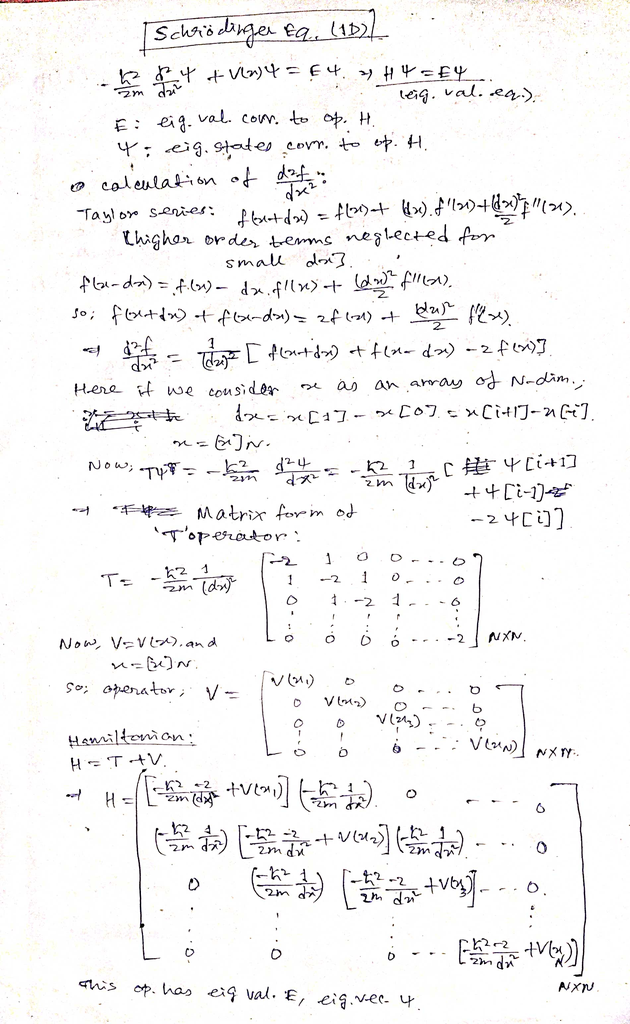

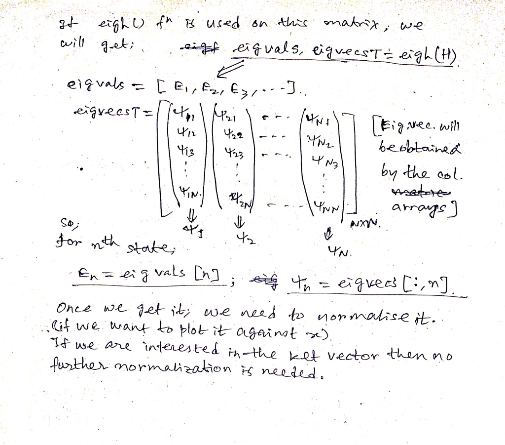

```python
from IPython.display import Image, display

display(Image(filename="notes_images/qm_notes_1.jpg"))
display(Image(filename="notes_images/qm_notes_2.jpg"))
```

```python
hcut = 1 # INPUT
mass = 1  # INPUT

hcut = const.hbar # INPUT
mass = const.electron_mass  # INPUT
```

## Potentials

Select a suitable potential and 'Run' only that desired potential.

### Potential Well:

$$ V(x) = -V_0 \quad ; \quad -\frac{a}{2}<x<\frac{a}{2} $$$$ = 0 \quad ; \quad otherwise $$

### Barrier Potential:

$$ V(x) = V_0 \quad ; \quad -\frac{a}{2}<x<\frac{a}{2} $$$$ = 0 \quad ; \quad otherwise $$

### Multiple Barriers:

Barrier height = $V_0$.

### Multiple Barriers:

Barrier height = $V_0$, number of barriers = $N_{barr}$.

### 1D LHO Potential:

$$ V(x) = \frac{1}{2} m\omega^2 x^2 $$

```python
L = 10    # INPUT
L = 10e-10  # INPUT
x_min, x_max = -L, L
N = 500    # no. of grid points
x = np.linspace(x_min, x_max, N)   # x axis

# potential
def potential1d(x, omega):
    return 0.5*mass*(omega**2)* x**2

omega1 = 1.0 # INPUT
omega1 = 12*const.electron_volt/const.hbar  # INPUT

Vx = potential1d(x=x, omega=omega1)
```

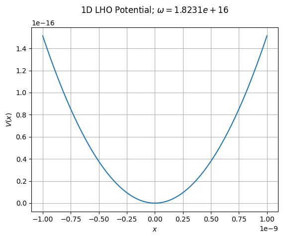

```python
plt.plot(x, Vx)
plt.title(f'1D LHO Potential; $\omega={omega1:.5}$\n')
plt.xlabel('$x$')
plt.ylabel('$V(x)$')
plt.grid()
plt.show()
```

### Nuclear Potential:

Potential depth = $V_0$, Potential height = $V_c$, Amomic no. = $Z$, Atomic mass no. = $A$. All the contants are inserted randomly.

### Potential 1:

$$ V(x) = k |x| $$

L = 10 x_min, x_max = -L, L N = 200 # no. of grid points x = np.linspace(x_min, x_max, N) # x axis # potential def potential1d(x, k): return k* np.abs(x) k1 = 1 # INPUT Vx = potential1d(x=x, k=k1) plt.plot(x, Vx) plt.xlabel('$x$') plt.ylabel('$V(x)$') plt.grid() plt.show()

### Sinusoidal Potential:

$$ V(x) = A \sin(kx) $$

L = 30 x_min, x_max = 0, L N = 200 # no. of grid points x = np.linspace(x_min, x_max, N) # x axis # potential def potential1d(x, A, k): return A* np.sin(k*x) A1, k1 = 5, 1 # INPUT Vx = potential1d(x=x, A=A1, k=k1) plt.plot(x, Vx) plt.xlabel('$x$') plt.ylabel('$V(x)$') plt.grid() plt.show()

## Plotting Wavefunction and Probability density

Using **`eigh`**

dx = x[1] - x[0] T = (-hcut**2/(2*mass)) * (np.diag(-2/dx**2 * np.ones(N)) + np.diag(1/dx**2 * np.ones(N-1), 1) + np.diag(1/dx**2 * np.ones(N-1), -1)) H = T + np.diag(Vx*np.ones(N)) eigenvals1, eigenvecsT1 = eigh(H) # eigenvecsT1m2 = eigenvecsT1.conjugate()*eigenvecsT1 def eig_val(n): return eigenvals1[n] def eig_vec(n): eigf = eigenvecsT1[:, n] eigfm2 = eigf.conjugate()*eigf eigf = eigf/simps(eigfm2, x)**0.5 return eigf def prob_den(n): igv = eigenvals1[n] eigf = eigenvecsT1[:, n] eigfm2 = eigf.conjugate()*eigf eigf = eigf/simps(eigfm2, x)**0.5 eigfm2 = eigf.conjugate()*eigf return eigfm2 n = 5 # INPUT plt.plot(x, Vx) plt.plot(x, eig_val(n)*np.ones(N)) plt.title('Potential') plt.xlabel('$x$') plt.ylabel('$V(x)$') plt.grid() plt.show() plt.figure(figsize=(12,5)) plt.tight_layout() plt.subplot(121) plt.plot(x, eig_vec(n)) plt.title(f'Eigenstate corresponding to $n={n}$, $E_n={eig_val(n):.6f}$\n') plt.xlabel('$x$') plt.ylabel(f'$\psi_n(x)$') plt.grid() plt.subplot(122) plt.plot(x, prob_den(n)) plt.title(f'Probability density corresponding to $n={n}$, $E_n={eig_val(n):.6f}$\n') plt.xlabel('$x$') plt.ylabel(f'$|\psi_n(x)|^2$') plt.grid() plt.show()

Using **`eigh_traditional`**

This method is needed to be modified as here the values of $\hbar$ and $m$ are not used.

dx = x[1] - x[0] d = 1/dx**2 + Vx e = -1/(2*dx**2) * np.ones(len(d)-1) eigenvals1, eigenvecsT1 = eigh_tridiagonal(d, e)

Using sparse matrices (**`eigsh`**)

```python
from scipy import sparse
from scipy.sparse.linalg import eigsh
```

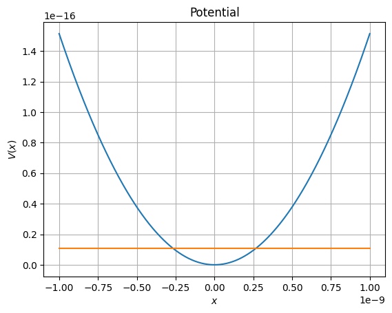

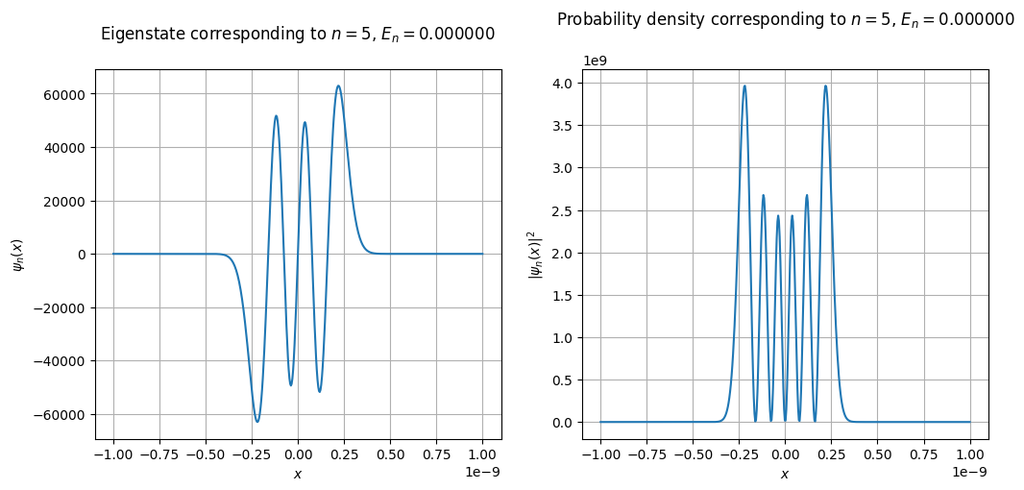

```python
dx = x[1] - x[0]
diags = np.array([np.ones(N), -2*np.ones(N), np.ones(N)])
D = sparse.spdiags(diags, np.array([-1,0,1]), N, N)
T = -hcut**2/(2*mass) * (1/dx**2) * D
V = sparse.diags(Vx, 0)
H = T + V
eigenvals1, eigenvecsT1 = eigsh(H, k=50, which='SM')

def eig_val(n):
    return eigenvals1[n]
def eig_vec(n):
    eigf = eigenvecsT1[:, n]
    eigf = eigf/np.sum(np.abs(eigf)**2*dx)**0.5
    return eigf
def prob_den(n):
    igv = eigenvals1[n]
    eigf = eigenvecsT1[:, n]
    eigf = eigf/np.sum(np.abs(eigf)**2*dx)**0.5
    return eigf.conjugate()*eigf

n = 5   # INPUT

plt.plot(x, Vx)
plt.plot(x, eig_val(n)*np.ones(N))
plt.title('Potential')
plt.xlabel('$x$')
plt.ylabel('$V(x)$')
plt.grid()
plt.show()

plt.figure(figsize=(12,5))
plt.tight_layout()
plt.subplot(121)
plt.plot(x, eig_vec(n))
plt.title(f'Eigenstate corresponding to $n={n}$, $E_n={eig_val(n):.6f}$\n')
plt.xlabel('$x$')
plt.ylabel(f'$\psi_n(x)$')
plt.grid()
plt.subplot(122)
plt.plot(x, prob_den(n))
plt.title(f'Probability density corresponding to $n={n}$, $E_n={eig_val(n):.6f}$\n')
plt.xlabel('$x$')
plt.ylabel(f'$|\psi_n(x)|^2$')
plt.grid()
plt.show()
```

```python
print(T.trace())
print(Vx.sum())
print(V.trace())
print(simps(prob_den(n), x))
```

```
3.7999198013928184e-13
2.533237376859993e-14
2.533237376859993e-14
0.9999999999999896
```

Different eigenstates in one graph

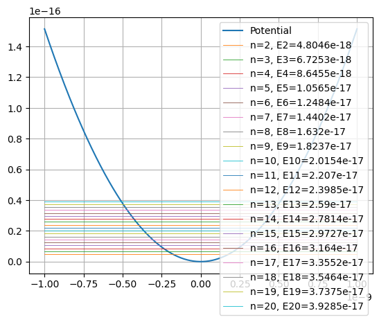

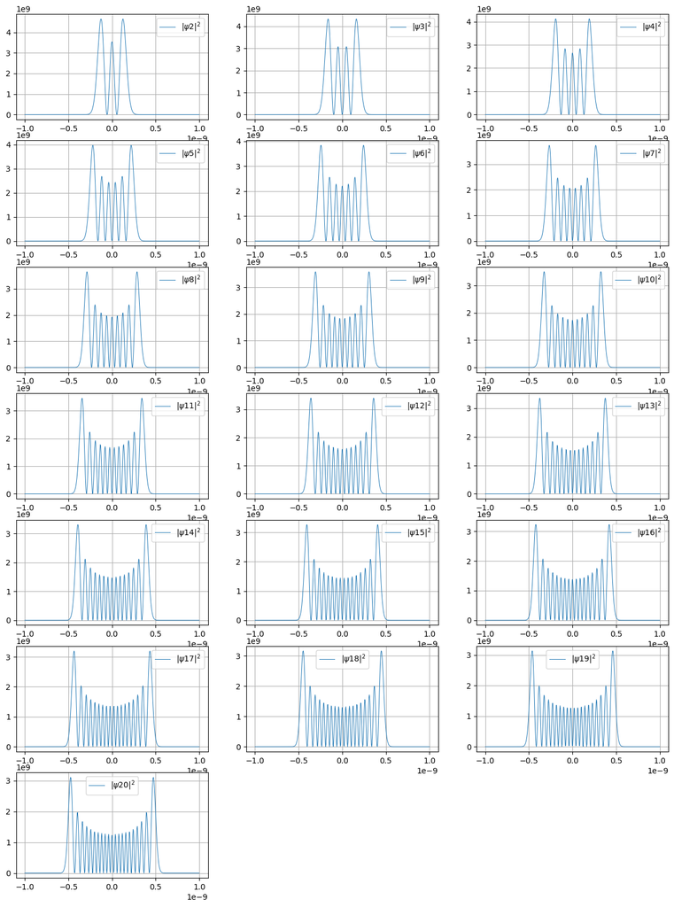

```python
nmin, nmax = 2, 20  # INPUT

plt.plot(x, Vx, label='Potential')
for i in range(nmin, nmax+1):
    plt.plot(x, eig_val(i)*np.ones(N), label=f'n={i}, E{i}={eig_val(i):.5}', lw=0.6)
plt.legend(loc='best')
plt.grid()
plt.show()

plt.figure(figsize=(15, 20)) # INPUT
# plt.tight_layout()
for i in range(nmin, nmax+1):
    plt.subplot((nmax+1-nmin)//3 +1, 3, i-nmin+1)
    # plt.plot(x, eig_vec(i), label=f'$\psi {i}$', lw=0.7) # for wavefunction
    plt.plot(x, prob_den(i), label=f'$|\psi {i}|^2$', lw=0.7) # for probability density
    plt.legend(loc='best')
    plt.grid()
plt.show()
```

Properties of Wavefunction:

m1, m2 = 14, 16 # INPUT psi1m,psi1n = eigvecsT1[:, m1], eigvecsT1[:, m2] psi2m,psi2n = eigvecsT2[:, m1], eigvecsT2[:, m2] print(f'comparison of 2 methods: expected=0, result={np.sum(np.abs(psi1m-psi2m))}') print(f'orthogonality: expected=0, result={np.sum(psi1m*psi1n)}, {np.sum(psi2m*psi2n)}') print(f'normalization check: expected=1, result={np.sum(psi1n*psi2n)}, {np.sum(psi2n*psi2n)}')

## Superposition

n1, n2 = 5, 7 # INPUT c1, c2 = 2, 5 # INPUT - no need to normalise, give you value c1, c2 = c1/(c1**2+c2**2)**0.5, c2/(c1**2+c2**2)**0.5 # normalisation psi1, psi2 = eig_vec(n1), eig_vec(n2) psi12 = (c1*psi1 + c2*psi2) plt.figure(figsize=(10,5)) plt.subplot(121) plt.plot(x, psi1, '--', label=f'$n_1={n1}$, $E_1={eig_val(n1):.4}$, $c_1={c1}$') plt.plot(x, psi2, label=f'$n_2={n2}$, $E_2={eig_val(n2):.4}$, $c_2={c2}$') plt.legend() plt.grid() plt.subplot(122) plt.plot(x, psi12, label='Superposition') plt.legend() plt.grid() plt.show()

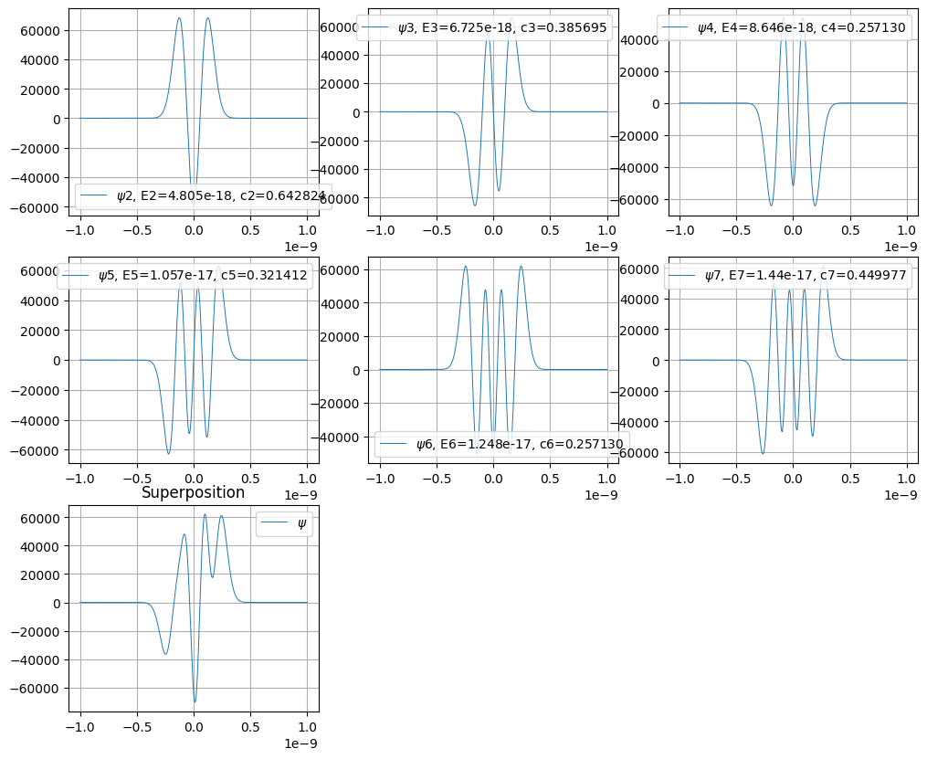

```python
ns = np.array([2,3,4,5,6,7])  # INPUT
cs = np.array([10, 6, 4, 5, 4, 7])   # INPUT
cs = cs/np.sum(cs**2)**0.5

plt.figure(figsize=(12, 10))  # maintain

psis = eig_vec(0)*0
for i in range(ns.size):
    psin = cs[i]*eig_vec(ns[i])
    psis += psin

    plt.subplot(ns.size//3+1, 3, i+1)
    plt.plot(x, eig_vec(ns[i]), lw=0.7,
            label=f'$\psi{ns[i]}$, E{ns[i]}={eig_val(ns[i]):.4}, c{ns[i]}={cs[i]:3f}')
#     plt.plot(x, prob_den(ns[i]), lw=0.7,
        #     label=f'$|\psi{ns[i]}|^2$, E{ns[i]}={eig_val(ns[i]):.4}, c{ns[i]}={cs[i]:3f}')
    plt.legend()
    plt.grid()

plt.subplot(ns.size//3+1, 3, ns.size+1)
plt.title('Superposition')
plt.plot(x, psis, label='$\psi$', lw=0.7)
# plt.plot(x, psis.conjugate()*psis, label='$|\psi|^2$', lw=0.7)
plt.legend()
plt.grid()
plt.show()
```

```python
simps(psis.conjugate()*psis, x)
```

```
0.9999999999999917
```

## Momentum space

$$ \psi(x) = \frac{1}{\sqrt{2\pi\hbar}} \int a(p) \exp(\frac{ipx}{\hbar}) \,dp $$

So, by Fourier transform, $$ a(p) = \frac{1}{\sqrt{2\pi\hbar}} \int \psi(x) \exp(-\frac{ipx}{\hbar}) \,dx $$

```python
# k = np.linspace(x_min, x_max, N*2) # INPUT - same kind of limit that of x
k = np.linspace(100/x_min, 100/x_max, N*2) # INPUT - same kind of limit that of 1/x
p = hcut*k

def eig_vec_pspace(p, psi):
    ap = []
    for pi in p:
        api = (1/np.sqrt(2*np.pi*hcut))*simps(psi*np.exp(-1j*pi*x/hcut), x)
        ap.append(api)
    return np.array(ap)

def prob_den_pspace(p, psi):
    return np.abs(eig_vec_pspace(p, psi))**2

def eig_vec_return(p, psi):
    psix = []
    for xi in x:
        psixi = (1/np.sqrt(2*np.pi*hcut))*simps(eig_vec_pspace(p, psi)*np.exp(1j*p*xi/hcut), p)
        psix.append(psixi)
    return np.array(psix)

def prob_den_return(p, psi):
    return np.abs(eig_vec_return(p, psi))**2
```

Momentum distribution

[output not shown]

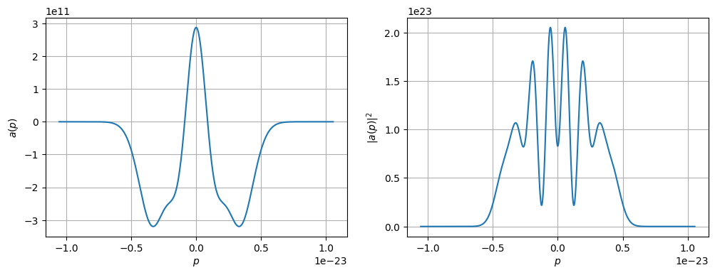

```python
psi = psis  # INPUT - wavefunction

print(f'Normalization check: {simps(prob_den_pspace(p, psi), p)}')
plt.figure(figsize=(12, 4))
plt.subplot(121)
plt.plot(p, eig_vec_pspace(p, psi))
plt.xlabel('$p$')
plt.ylabel('$a(p)$')
plt.grid()
plt.subplot(122)
plt.plot(p, prob_den_pspace(p, psi))
plt.xlabel('$p$')
plt.ylabel('$|a(p)|^2$')
plt.grid()
plt.show()
```

## Expectation values and Uncertainty

```python
psi = eig_vec(2) # INPUT

def expectation_val_x(psi):
    return simps(x*np.abs(psi)**2, x)
def expectation_val_x2(psi):
    return simps(x**2*np.abs(psi)**2, x)
def uncertainty_x(psi):
    return np.sqrt(expectation_val_x2(psi)-(expectation_val_x(psi)**2))

def expectation_val_p(psi):
    return simps(p*prob_den_pspace(p, psi), p)
def expectation_val_p2(psi):
    return simps(p**2*prob_den_pspace(p, psi), p)
def uncertainty_p(psi):
    return np.sqrt(expectation_val_p2(psi)-(expectation_val_p(psi)**2))
def uncertainty_xp(psi):
    return uncertainty_x(psi)*uncertainty_p(psi)

print(uncertainty_xp(psi))
```

```
2.6364295538589125e-34
```

```python
2.5*hcut  # exact value (for LHO)
```

```
2.636429544115391e-34
```

A way to the selection rule

```python
def transition_check(m, n):
    return simps(eig_vec(m).conjugate()*x*eig_vec(n), x)

m = 4 # INPUT
for i in range(m-3, m+4):
    print(f'm={m}, n={i}, <m|x|n> = {transition_check(m, i)}')
```

```
m=4, n=1, <m|x|n> = -2.184888685517441e-14
m=4, n=2, <m|x|n> = -4.229607116530911e-24
m=4, n=3, <m|x|n> = -1.1262264092387285e-10
m=4, n=4, <m|x|n> = -4.1488277598362794e-24
m=4, n=5, <m|x|n> = -1.2589595842616764e-10
m=4, n=6, <m|x|n> = 1.172916259206051e-24
m=4, n=7, <m|x|n> = -6.470683954598094e-14
```

## Time Evolution

$$ \psi(x) = \frac{1}{\sqrt{2\pi}} \int a(k) \exp(ikx) dk $$

So, by Fourier transform, $$ a(k) = \frac{1}{\sqrt{2\pi}} \int \psi(x) \exp(-ikx) dx $$

The time dependent wavefunction is, $$ \Psi(x, t) = \frac{1}{\sqrt{2\pi}} \int a(k) \exp(ikx-i\omega(k)t) dk $$ where, $\omega(k)$ will be according to the dispersion relation of the medium.

In k space

Checking accuracy of Fourier Transform

print('checking accuracy of Fourier Transform') print(np.sum(np.abs(np.abs(psis))**2-prob_den_return(k, psis))) print(np.sum(np.abs(np.abs(psis))**2-time_dep_prob_den(t, k, psis)[0])) plt.plot(x, psis, label='original wavefunction') plt.plot(x, eig_vec_return(k, psis), label='after IFT') plt.plot(x, time_dep_wavefn(t, k, psis)[0], label='at t=0') plt.xlabel('$x$') plt.ylabel('$\Psi(x, t=0)$') plt.legend() plt.grid() plt.show()

The correct time evolution cannot be obtained until we know the proper form of $\omega(k)$.

Wavefunction

timecount = 0 plt.figure(figsize=(10, 7)) # INPUT for psix in time_dep_wavefn(t, k, psis): plt.subplot(t.size//3 +1, 3, timecount+1) plt.plot(x, psix, label=f't={t[timecount]:.6f}') timecount += 1 plt.grid() plt.legend() plt.show()

Probability Density

timecount = 0 plt.figure(figsize=(10, 7)) # INPUT for psix in time_dep_prob_den(t, k, psis): plt.subplot(t.size//3 +1, 3, timecount+1) plt.plot(x, psix, label=f't={t[timecount]:.6f}') timecount += 1 plt.grid() plt.legend() plt.show()

## QuTip Analysis

```python
import qutip as qp
```

```python
H_oper = qp.Qobj(H)
H_oper
```

Quantum object: dims = [[500], [500]], shape = (500, 500), type = oper, isherm = True $ \\ \left(\begin{matrix}9.114\times10^{-16} & -3.800\times10^{-16} & 0.0 & 0.0 & 0.0 & \cdots & 0.0 & 0.0 & 0.0 & 0.0 & 0.0\\-3.800\times10^{-16} & 9.102\times10^{-16} & -3.800\times10^{-16} & 0.0 & 0.0 & \cdots & 0.0 & 0.0 & 0.0 & 0.0 & 0.0\\0.0 & -3.800\times10^{-16} & 9.090\times10^{-16} & -3.800\times10^{-16} & 0.0 & \cdots & 0.0 & 0.0 & 0.0 & 0.0 & 0.0\\0.0 & 0.0 & -3.800\times10^{-16} & 9.078\times10^{-16} & -3.800\times10^{-16} & \cdots & 0.0 & 0.0 & 0.0 & 0.0 & 0.0\\0.0 & 0.0 & 0.0 & -3.800\times10^{-16} & 9.066\times10^{-16} & \cdots & 0.0 & 0.0 & 0.0 & 0.0 & 0.0\\\vdots & \vdots & \vdots & \vdots & \vdots & \ddots & \vdots & \vdots & \vdots & \vdots & \vdots\\0.0 & 0.0 & 0.0 & 0.0 & 0.0 & \cdots & 9.066\times10^{-16} & -3.800\times10^{-16} & 0.0 & 0.0 & 0.0\\0.0 & 0.0 & 0.0 & 0.0 & 0.0 & \cdots & -3.800\times10^{-16} & 9.078\times10^{-16} & -3.800\times10^{-16} & 0.0 & 0.0\\0.0 & 0.0 & 0.0 & 0.0 & 0.0 & \cdots & 0.0 & -3.800\times10^{-16} & 9.090\times10^{-16} & -3.800\times10^{-16} & 0.0\\0.0 & 0.0 & 0.0 & 0.0 & 0.0 & \cdots & 0.0 & 0.0 & -3.800\times10^{-16} & 9.102\times10^{-16} & -3.800\times10^{-16}\\0.0 & 0.0 & 0.0 & 0.0 & 0.0 & \cdots & 0.0 & 0.0 & 0.0 & -3.800\times10^{-16} & 9.114\times10^{-16}\\\end{matrix}\right)$

Verifying previous results

```python
def psi_n_ketvector(n):
    return qp.Qobj(eigenvecsT1[:,n])

psi4ketv = psi_n_ketvector(4)
psi5ketv = psi_n_ketvector(5)
display(psi5ketv.dag()*psi5ketv)

eigenvecsT2 = H_oper.eigenstates()  # a set of all eigvals and corresponding eigkets
# display(eigenvecsT2)
state4 = np.array(eigenvecsT2)[:,4]
print(eigenvals1[4], state4[0])
state4ket = state4[1]
state4ketarr = np.array(state4[1]).T[0]
display(psi4ketv.dag()*state4ket)
```

Quantum object: dims = [[1], [1]], shape = (1, 1), type = bra $ \\ \left(\begin{matrix}1.000\\\end{matrix}\right)$

```
8.645517484144673e-18 8.645517484144772e-18
```

Quantum object: dims = [[1], [1]], shape = (1, 1), type = bra $ \\ \left(\begin{matrix}-1.000\\\end{matrix}\right)$

Solving independently in qutip by known operator

```python
H_oper =  qp.Qobj(H)
H_states = H_oper.eigenstates()
H_values = H_oper.eigenenergies()

def H_eigenvalue(n):
    # return H_values[n] # alternative
    return np.array(H_states)[:,n][0]
def H_eigenket(n):
    return np.array(H_states)[:,n][1]
def H_eigenket_arr(n):
    return np.array(H_eigenket(n)).T[0]
```

```python
display(H_eigenket(14).dag()*H_oper*H_eigenket(14), H_eigenvalue(14))
```

Quantum object: dims = [[1], [1]], shape = (1, 1), type = bra $ \\ \left(\begin{matrix}0.0\\\end{matrix}\right)$

```
2.7813735692441464e-17
```

```python
a = qp.destroy(N)
adag = qp.create(N)
display(H_eigenket(3).dag()*a*H_eigenket(5)) # not working
```

Quantum object: dims = [[1], [1]], shape = (1, 1), type = bra $ \\ \left(\begin{matrix}-0.087\\\end{matrix}\right)$